If a matrix does not have a rank equal to the number of its columns, this can cause problems in some of our calculations.

```r
MA <- matrix(data = c(1, 2, 6, 3, 4, 12, 5, 6, 18),
             nrow = 3,
             ncol = 3,
             byrow = TRUE)
MA
```

```
##      [,1] [,2] [,3]
## [1,]    1    2    6
## [2,]    3    4   12
## [3,]    5    6   18
```

**Inverse of a Matrix**

The inverse of a scalar, say $b$, is $b^{-1}$. For example, the inverse of $b = 3$ is $3^{-1} = {1/3}$. Also, $b*b^{-1} = 1$.

In matrix algebra, the inverse of a matrix is another matrix.

For example, the inverse of $A$ is $A^{-1}$, and $AA^{-1} = A{^-1}A = I$. Note that $A must be a square matrix.

$A$

```r
MA <- matrix(data = 1:4,
             nrow = 2,
             ncol = 2,
             byrow = TRUE)
MA
```

```
##      [,1] [,2]
## [1,]    1    2
## [2,]    3    4
```

$A^{-1}$

```r
MA_up_to_minus_one <- matrix(data = c(-2, 1, 1.5, -0.5),
                             ncol = 2,
                             nrow = 2,
                             byrow =TRUE)
MA_up_to_minus_one
```

```
##      [,1] [,2]
## [1,] -2.0  1.0
## [2,]  1.5 -0.5
```

```r
MA %*% MA_up_to_minus_one
```

```
##      [,1] [,2]
## [1,]    1    0
## [2,]    0    1
```

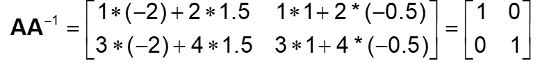

**Finding the inverse**

For a 2x2 matrix, there is a simple formula.

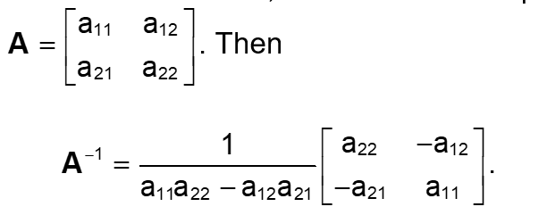

For larger matrix we rely on R.

Exercices

```r
MA <- matrix(data = 1:4,
             nrow = 2,
             ncol = 2,
             byrow = TRUE)
solve(MA)
```

```
##      [,1] [,2]
## [1,] -2.0  1.0
## [2,]  1.5 -0.5
```

```r
MA %*% solve(MA)
```

```
##      [,1]         [,2]
## [1,]    1 1.110223e-16
## [2,]    0 1.000000e+00
```

```r
solve(MA) %*% MA
```

```
##      [,1]         [,2]
## [1,]    1 4.440892e-16
## [2,]    0 1.000000e+00
```

```r
round(solve(MA) %*% MA, 2)
```

```
##      [,1] [,2]
## [1,]    1    0
## [2,]    0    1
```

In R the `solve()` inverts a matrix. The `solve(MA, Mb)`, function can also be used to *solve* for $x$ in $Ax = b$ since $A^{-1}Ax = A^{-1}b \rightarrow Ix = A^{-1}b \rightarrow A^{-1}b$

Example with `gpa` dataset

- Find $(X'X)^{-1}$
- Find $(X'X)^{-1}X'Y$

```r
solve(t(X) %*% X)
```

```
##            [,1]       [,2]
## [1,]  1.1378689 -0.3752566
## [2,] -0.3752566  0.1294435
```

```r
solve(t(X) %*% X) %*% t(X) %*% Y
```

```
##           [,1]
## [1,] 1.0868795
## [2,] 0.6124941
```

Thus,
$$(X'X)^{-1}X'Y =
\begin{bmatrix} \hat{\beta}_0 \\ \hat{\beta}_1 \end{bmatrix}$$
, where $\hat{\beta}_0$ and $\hat{\beta}_1$ are the estimated intercept and slope coefficients in a simple linear regression model.

We can confirm by making a fitted model.

```r
mod.fit <- lm(CollegeGPA ~ HSGPA, data = gpa)
mod.fit$coefficients
```

```
## (Intercept)       HSGPA
##   1.0868795   0.6124941
```

**Trace**

Suppose a square matrix $A$

Trace - The trace of a square matrix $A$ is defined as $tr(A) = \overset{p}{\underset{i=1}{\sum}} a_{ij} = a_{11} + a_{22} + ... a_{pp}$; i.e., the sum of a square matrix diagonal elements.

```r
MA <- matrix(data = 1:4,
             nrow = 2,
             ncol =2,
             byrow = TRUE)
MA
```

```
##      [,1] [,2]
## [1,]    1    2
## [2,]    3    4
```

```r
diag(MA)
```

```
## [1] 1 4
```

```r
sum(diag(MA))
```

```
## [1] 5
```

The covariance `cov()` is simillar to the correlation `corr()`. What changes is that the `cov()` is not bounded to -1 and 1.

$$corr(x_1, x_2) = \frac{cov(x_1, x_2)
}{(\sqrt(var(x_1) * \sqrt(var(x_2))}$$
Taking the sum of the diagonal of a covariance matrix would tell all the variability of the data, important for the PCA analysis.

**Determinant**

The determinant of a square matrix $A$ is $|A| = \overset{p}{\underset{i=1}{\sum}} a_{ij}A_{ij} where A_{1j} = (-1)^{1+j}|A^{1j}|$ and $A^{1j}$ is obtained from $A$ by deleting its first row and its $j^{th}$ columns.

The determinant for a 2x2 matrix is defined as

$$\begin{bmatrix} a_{11} \ a_{12} \\
a_{21} \ a_{22} \end{bmatrix} = a_{11}a_{22} - a_{12}a_{21}$$

That is, the product of the diagonal elements $a_{11}, a_{22}$ minus the product of the off diagonal elements $a_{12}, a_{21}$

The determinant for a 3x3 matrix can be defined as

$$\begin{bmatrix} a_{11} \ a_{12} \ a_{13}
\\ a_{21} \ a_{22} \ a_{23} \\ a_{31} \ a_{32} \ a_{33} \end{bmatrix} =
a_{11} \begin{bmatrix} a_{22} \ a_{23} \\ a_{32} \ a_{33} \end{bmatrix}
- a_{12} \begin{bmatrix} a_{21} \ a_{23} \\ a_{31} \
a_{33} \end{bmatrix} + a_{13} \begin{bmatrix} a_{21} \ a_{22} \\ a_{31}
\ a_{32} \end{bmatrix}$$
In 3x3 matrix we form 2x2 matrices with elements of the 3x3 matrix. For instance, the
$$\begin{bmatrix} a_{22} \ a_{23} \\ a_{32} \
a_{33} \end{bmatrix}$$

is an extracted of the 3x3 matrix and is being multiplied by the first element of the original 3x3 matrix $a_{11}$. This multiplications happens with the element that is not in the same row or column of the extracted matrix.

Fallowing, the
$$\begin{bmatrix} a_{21} \
a_{23} \\ a_{31} \ a_{33} \end{bmatrix}$$

is and extracted of the 3x3 matrix and fallow the same pattern, being multiplied by the $a_{12}$ element, that is not in the same row or column of the extracted matrix from the 3x3 matrix

```r
MA <- matrix(data = c(1, 2, 3, 4),
             nrow = 2,
             ncol = 2,
             byrow = TRUE)
MA
```

```
##      [,1] [,2]
## [1,]    1    2
## [2,]    3    4
```

```r
det(MA)
```

```
## [1] -2
```

**Eingenvalues and eigenvectors**

Suppose we have a pxp matrix $A$, being square matrix.

$$A = \begin{bmatrix} a_{11} \ a_{12} \
... \ a_{1p} \\ a_{21} \ a_{22} \ ... \ a_{2p} \\ ... \\ a_{p1} \ a_{p2}
\ a_{pp} \end{bmatrix}$$

Eingenvalues - Are the roots of the polynomial equation defined by $|A - \lambdaI| = 0$ where $I$ is an identity matrix and $\lambda$ is a constant. We then find the determinant of that, set all to zero and solved for $\lambda$. The $\lambda$ we find in the end is the *Eingenvalues*

if $p = 2$, then the eigenvalues are the roots of

$$\begin{bmatrix} a_{11} \ a_{12} \\
a_{21} \ a_{22} \end{bmatrix} - \begin{bmatrix} \lambda \ 0 \\ 0 \
\lambda \end{bmatrix} = \begin{bmatrix} a_{11} - \lambda \ a_{12} \\
a_{21} \ a_{22} - \lambda \end{bmatrix}$$

$$= (a_{11} - \lambda) (a_{22} - \lambda)
- a_{21}a_{12}$$

$$= \lambda^2 - \lambda(a_{11} + a_{22}) -
(a_{21}a_{12} - a_{11}a_{22}) = 0$$

Using the quadratic formula, we obtain

$$\lambda = \frac {a_{11} + a_{22} \pm
\sqrt{(a_{11} + a_{22})^2 + 4(a_{21}a_{12} - a_{11}a_{22})}} 2$$

In general, the eigenvalues are the p roots of $c_{1}\lambda^{p} + c_{2}\lambda^{p-1} + c_{3}\lambda^{p-2} + ... + c_{p}\lambda + c_{p+1} = 0$ where $c_i$ for $i = 1, ..., p+1$ denote constants.

When $A$ is symmetric matrix, the eigenvalues are real numbers and can be ordered from largest to smallest as $\lambda_1 \ge \lambda_2 \ge ... \ge \lambda_p$ where $\lambda_1$ is the largest.

```r
MA <- matrix(data = c(1, 0.5, 0.5, 1.25),
             nrow = 2,
             ncol = 2,
             byrow = TRUE)
MA
```

```
##      [,1] [,2]
## [1,]  1.0 0.50
## [2,]  0.5 1.25
```

```r
save_eigen <- eigen(MA)
save_eigen
```

```
## eigen() decomposition
## $values
## [1] 1.6403882 0.6096118
##
## $vectors
##           [,1]       [,2]
## [1,] 0.6154122 -0.7882054
## [2,] 0.7882054  0.6154122
```

```r
save_eigen$values
```

```
## [1] 1.6403882 0.6096118
```

```r
save_eigen$vectors
```

```
##           [,1]       [,2]
## [1,] 0.6154122 -0.7882054
## [2,] 0.7882054  0.6154122
```

$$\lambda = \frac {2.25 \pm \sqrt{(2.25^2
+ 4(0.25 - 1.25))}} 2$$

This is equal to $1.6404$ and $0.6096$

Eigenvectors - Each eigenvalue of $A$ has a corresponding nonzero vector $b$ called an eigenvector that satisfies $Ab = \lambda b$. If i take $Ab$ where $b$ is an eigenvector this will be equal to $\lambda b$. So, values of $b$ that satisfied this relationship are called eigenvectors.

Eigenvectors for a particular eigenvalue are not unique. They are also given as having a length of 1. When two eigenvalues are not equal, their corresponding eigenvecctors are orthogonal (i.e., $b_{i}'b_j = 0$).

If i would take the trace of matrix $A$ that is the sum of the eigenvalues $tr(A) = \sum{\lambda_i}$